# Inspection of Economy by Currency, Gold and Inflation Data

# Object of the Study

In this study, it will be inspected and interpreted that the change in some data collected from [EVDS](https://evds2.tcmb.gov.tr/). This data is stored in 4 columns, which are Date (Months numbered from 01.2018 to 12.2020), Dollar-TL, Gold and inflation indicator (TUFE). In order to make use of grapichs easily, date will be shown in a numbered way ranged from 1 to 36.

# Introduction

As it is known, there are strong indicators of the economic situation of a country. Some of them are as listed:  
1) the rate position of local currency to foreign country  
2) the value of the means of reliable investment particularly gold  
3) indicators of inflation such as Consumer Price Index and Producer Price Index.  
There are more indicators of economic situations but in this study these 3 will be examinded for a wise conclusion. The values and rates will be interpreted by histograms, plot tables and more complex graphics. Then google trends research of “economic crisis”,which is “ekonomik kriz” in Turkish, help us understand the relationship between economic condition of Turkey and the expectancy of its people.

# Histogram Analysis

## Dollar-TL Rate

Histogram of Dollar-TL rate is shown below:

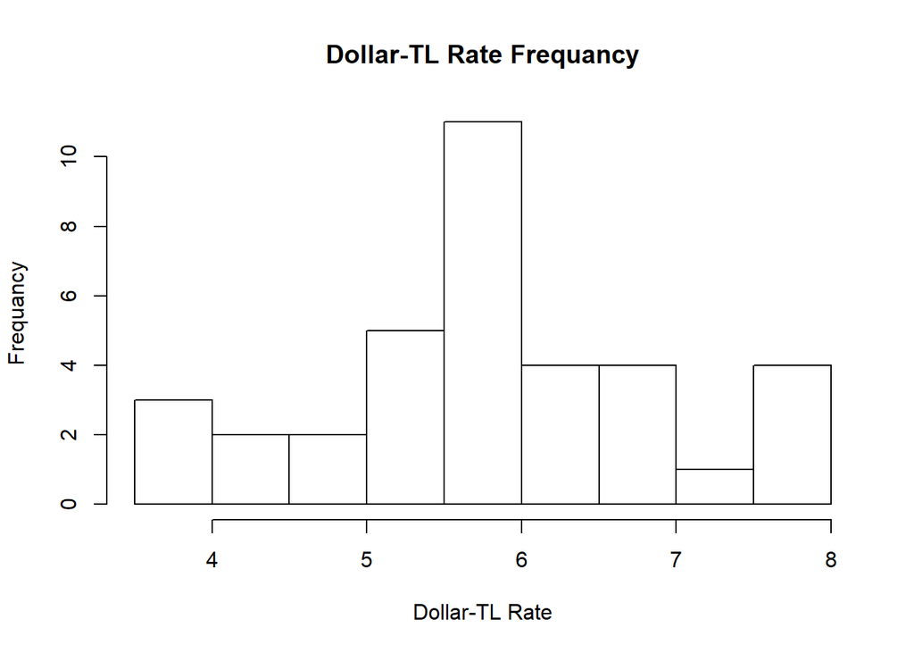

As it seems clearly, rate is mostly around 5.8-6 Tl per dollar. However, more detailed examination is required to understand trend of decrease or increase.

## Gold-TL Rate

Histogram of Gold (Cumhuriyet Altını) -TL rate is shown below:

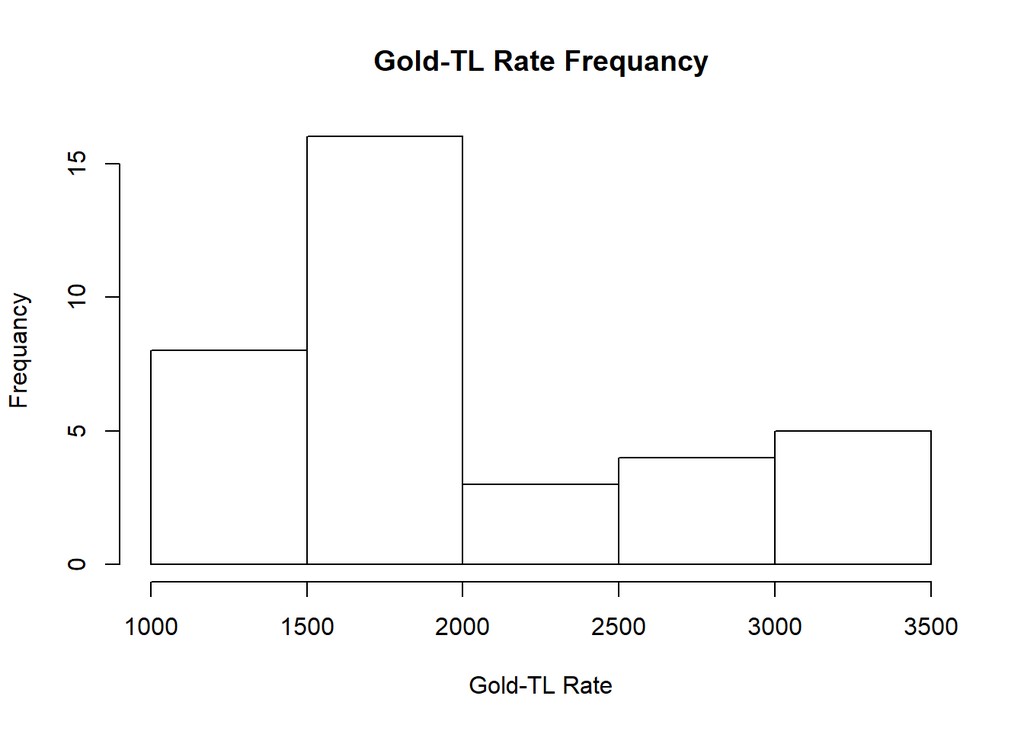

According to histogram result, gold value is not distributed normally. Its value mostly equals to 1500 or 2000.

## TUFE (Comsumer Price Index)

Histogram of the value of TUFE is shown below:

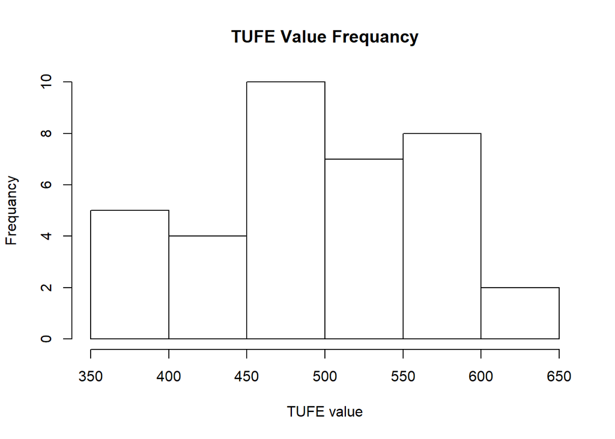

To interpret the graph, it does not distribute normally however values have more probability to be around 450-500.

# Plots of Indicators

## Dollar-TL Rate

The plot is given below:

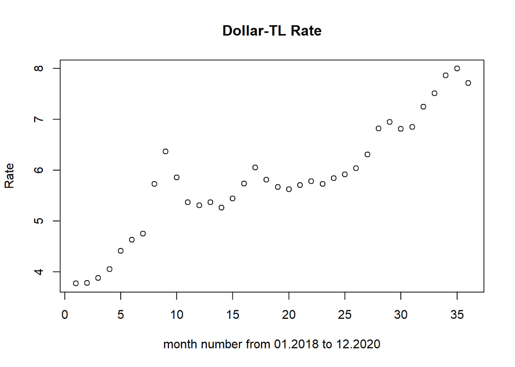

It would not be wrong to say that dollar gains more value against Turkish Liras each passing month. There is a clear increasing trend and if government does not take precaution, value will be even higher.

## Gold-TL Rate

The plot is given below:

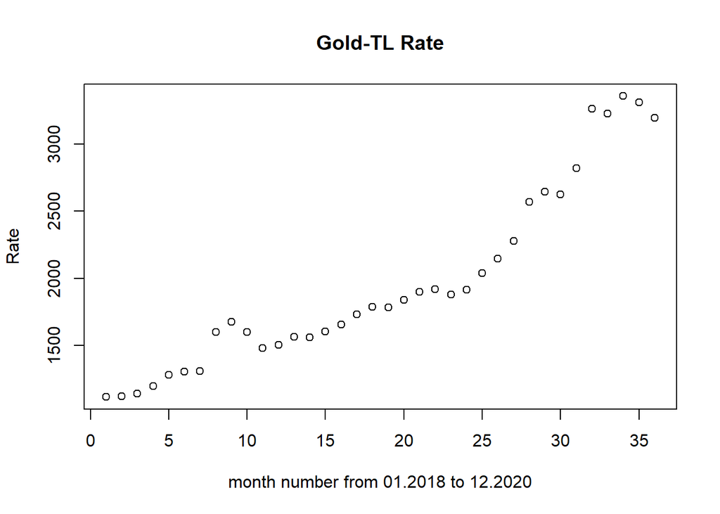

Gold is getting more valuable too. There is an increasing trend but it should be mentioned that after 30.month (06.2020) the increase is even higher than normal cases. There is a visible jump on the value of gold. The reason should be resulted from uncertainty of covid-19 and possible move to reliable means of investment.

## TUFE (Comsumer Price Index)

The plot is given below:

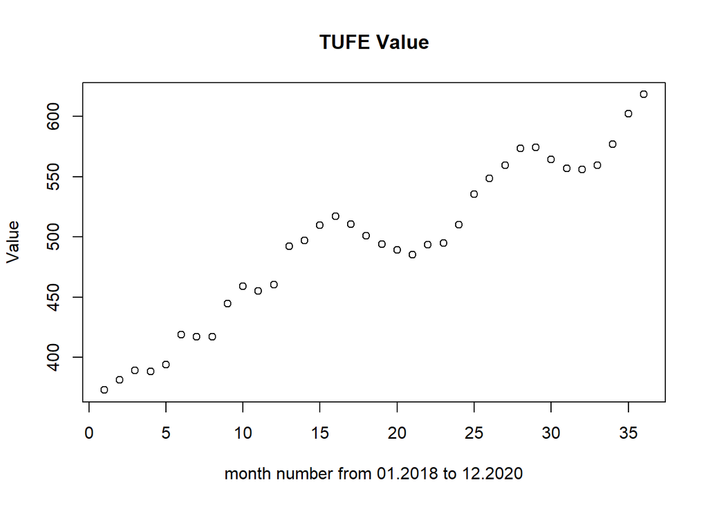

# Graphical Analysis of Indicators

## Dollar-TL Rate

The rate of dollar-tl is nearly doubled in 3 years. As it is said above, there is an increasing trend in the indicator. Around the 9th month, there is an unexpected increase and then it becomes normal at 12nd month. These 4 months should be investigated. The unusual jump of the rate must stem from Brunson crisi in Turkey and some other political crisis like F-35 case. The graphs tells us government should take precaution to stop devaluation of TL. If the reason of the increase is about export strategy, there may be no problem but Turkey is a import dependent country when it comes to export. So, problem may be even deeper and authorities must be aware of the current condition. Moreover, there are no monthly similarity over the years, it increases nearly permanently over 36 months.

## Gold-TL Rate

As it is mentioned above, gold acquires more value each passing month. There are no similarity over the 3 years. But last months tells the effect of covid-19 must be examined to make strategies. People tend to invest in gold to overcome uncertainity of the pandemy. That’s why the increase is even more in the last months.

## TUFE (Comsumer Price Index)

TUFE value has a tendancy to increase each passing month. This might result in an inflation in Turkey. There is an increasing trend without unexpected results according to graphs. But the seasonality should be investigated in further researchs. The similarity might tell us something because the increase is not as sharp as it is in Dollar-Tl rate and Gold-TL rate.

# Google Trend Interpretation

Google trend data is hold in dfr and in order to transform weekly data into monthly data, some operations are executed.

```r
mtr=matrix(dfr$Popularity, nrow=39, ncol=4)
mtr2=matrix(1:39, nrow=39, ncol=1)
for(i in 1:39) {
  count=0
  for(j in 1:4){
    count=count+mtr[i,j]
  }
  mtr2[i,1]=count/4
  trendframe=data.frame(Popularity = head(mtr2, 36L), months  = 1:36)
}
```

Now we can have an idea of comparing 3 economic indicators and search results for the keyword “economic crisis”

## Histogram and Plot of Google Trends Result

Histogram is shown below:

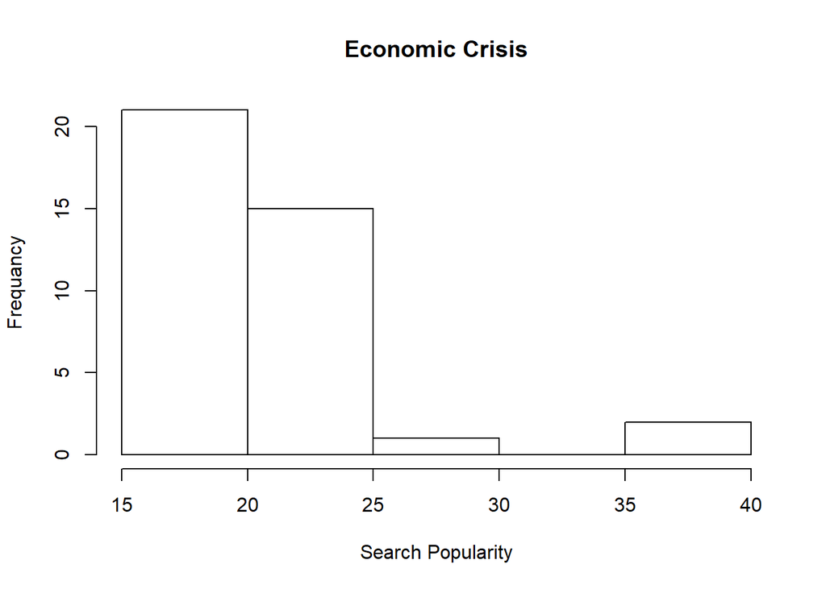

[figure not shown]

As far as it seems, popularity of the keyword is mostly around 20. Actually 20 is not low popularity and that can be interpreted as most of the citizens of Turkey generally search for “Economic Crisis” term. Plot graph does not tell as so much in this case.

## Line and Column Graph of Google Trends Result

Line graph is shown below:

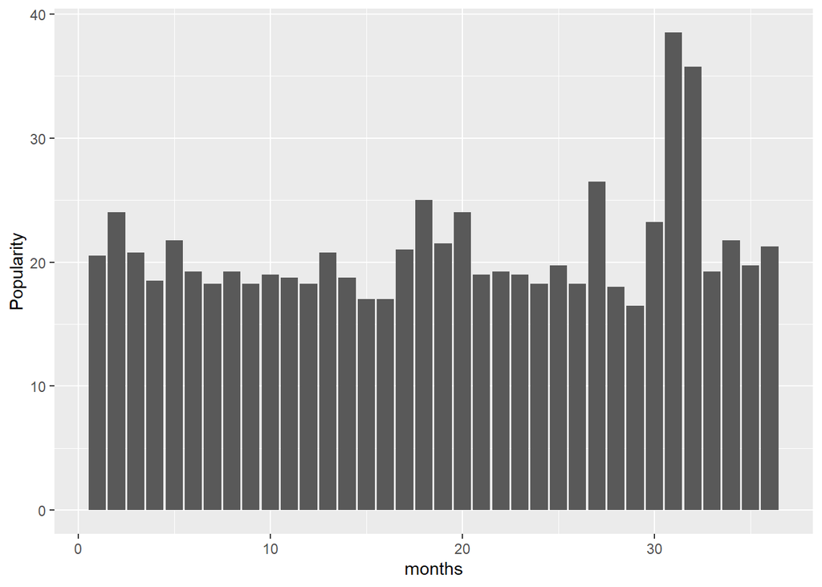

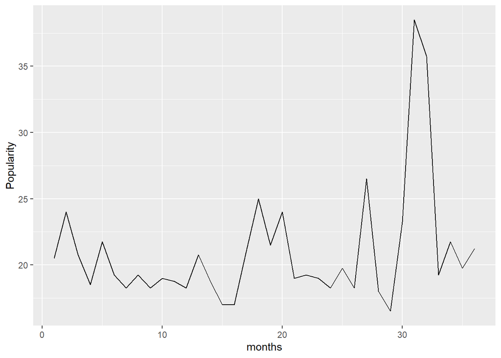

In these graphs, more complex interpretations can be done. Search volume is fluctuating around 20-25 and they have a pattern. However, it is also strange that after 30. month, search volume has an enormous jump which is the time period that covid-19 has become more vital problem in the country. The economic effects of the pandemic should be investigated in a more detailed way.

# Conclusion